# Estudis d'Informàtica, Multimedia i Telecomunicacions

# M2.959 - PAC2 - Raincloud Plot

Autor: Carles Sanchez Vilaro

Abril 2025

# 1 Context

Font: https://www.kaggle.com/datasets/mysarahmadbhat/wine-tasting

# 2 Carrega de dades i llibreries

Carreguem les llibreries necessàries i el conjunt de dades.

```r
llibreries <- c("knitr",
                "dplyr",
                "ggplot2",
                "ggrain")

llibreries_a_instalar <- llibreries[!(llibreries %in% installed.packages()[,"Package"])]
if(length(llibreries_a_instalar)) install.packages(llibreries_a_instalar)

llibreries_carregades <- lapply(llibreries, library, character.only = TRUE)

resultats_tast_vins <- read.csv("winemag-data-130k-v2.csv")
glimpse(resultats_tast_vins)
```

```
## Rows: 129,971
## Columns: 14
## $ id                    <int> 0, 1, 2, 3, 4, 5, 6, 7, 8, 9, 10, 11, 12, 13, 14…
## $ country               <chr> "Italy", "Portugal", "US", "US", "US", "Spain", …
## $ description           <chr> "Aromas include tropical fruit, broom, brimstone…
## $ designation           <chr> "Vulkà Bianco", "Avidagos", "", "Reserve Late Ha…
## $ points                <int> 87, 87, 87, 87, 87, 87, 87, 87, 87, 87, 87, 87, …
## $ price                 <int> NA, 15, 14, 13, 65, 15, 16, 24, 12, 27, 19, 30, …
## $ province              <chr> "Sicily & Sardinia", "Douro", "Oregon", "Michiga…
## $ region_1              <chr> "Etna", "", "Willamette Valley", "Lake Michigan …
## $ region_2              <chr> "", "", "Willamette Valley", "", "Willamette Val…
## $ taster_name           <chr> "Kerin O’Keefe", "Roger Voss", "Paul Gregutt", "…
## $ taster_twitter_handle <chr> "@kerinokeefe", "@vossroger", "@paulgwine ", "",…
## $ title                 <chr> "Nicosia 2013 Vulkà Bianco  (Etna)", "Quinta dos…
## $ variety               <chr> "White Blend", "Portuguese Red", "Pinot Gris", "…
## $ winery                <chr> "Nicosia", "Quinta dos Avidagos", "Rainstorm", "…
```

Descrivim les variables:

- **id** Identificador únic de cada tast.
- **country** País d’origen del vi.
- **description** Descripció sensorial del vi.
- **designation** Indica si el vi esta emparat per alguna denominació d’origen.
- **points** Puntuació donada al vi pels experts.
- **price** Preu del vi.
- **province** Regió vinícola dins del país.
- **region_1** Subregió vinícola més específica.
- **region_2** Detall addicional sobre la subregió vinícola.
- **taster_name** Nom del crític.
- **taster_twitter_handle** Nom d’usuari de Twitter del crític.
- **title** Nom complet del vi, incloent l’any, el celler i la denominació.
- **variety** Tipus de raïm utilitzat en l’elaboració del vi.
- **winery** Nom del celler que ha produït el vi.

# 3 Raincloud Plot

Creem el gràfic centrant-nos en els grans rivals vinícoles del Mediterrani: Espanya, Portugal, França i Itàlia. A més, incorporem price com a covariable per donar color als punts, destacant així la relació entre la puntuació i el preu del vi.

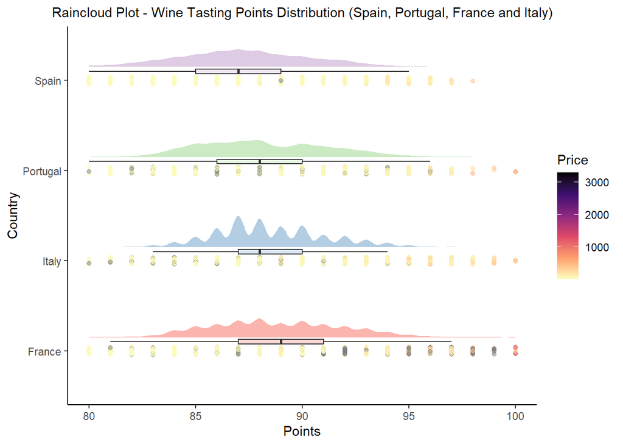

```r
resultats_tast_vins <- resultats_tast_vins %>%
  filter(country %in% c("Spain", "Portugal", "France", "Italy"))

ggplot(resultats_tast_vins, aes(country, points, fill = country)) +
  geom_rain(alpha = .5,
            cov = "price",
            violin.args = list(color = NA)) +
  theme_classic() +
  theme(plot.title = element_text(hjust = 0.5, size = 11)) +
  scale_fill_brewer(palette = "Pastel1") +
  scale_color_viridis_c(option =  "A", direction = -1) +
  guides(fill = "none") +
  coord_flip() +
  labs(title = "Raincloud Plot - Wine Tasting Points Distribution (Spain, Portugal, France and Italy)",
       x = "Country",
       y = "Points",
       color = "Price")
```

# 4 Conclusió

Aquest raincloud plot mostra la distribució de les puntuacions en l’anàlisi sensorial de vins d’Espanya, Portugal, França i Itàlia. Les puntuacions de tast són relativament similars entre aquests països, però Espanya presenta valors lleugerament més baixos, mentre que França té la mediana més alta.

Itàlia presenta la part del gràfic de densitat amb una distribució altament variable, indicant una concentració desigual de puntuacions. Contrariament, el boxplot italià és més compacte, suggerint menys variabilitat en les puntuacions respecte als altres països.